# Gene pool-specific genomic relationship matrices

Juliette Archambeau

14 novembre, 2020

> This document is based on the method of Muff et al. (2019).

# 1 Model equation based on equation 4 in [Muff et al. (2019)](https://gsejournal.biomedcentral.com/track/pdf/10.1186/s12711-019-0449-7)

Comment: In their paper, Muff et al. estimate the **additive genetic variance** and the associated **breeding values**. In our case, we estimate the **total genetic variance** (as we have clones and not families) and the associated **genetic values**.

In this model, we want to both take into account the population structure and potentially heterogeneous total genetic variances between gene pools. For that, we can use the following equation:

$$\begin{equation}
y_{g} \sim \mathcal{N}( \beta_{0} + \sum_{j=1}^{r} q_{gj}g_{j} + \sum_{j=1}^{r} u_{gj}, \sigma_{g}^{2})
\end{equation}$$

- The **population structure** is considered in the term: $\sum_{j=1}^{r} q_{gj}g_{j}$. In this term,
  - $q_{gj}$ is the proportional contribution of the gene pool $j$ to the genome of the genotype $g$ estimated in Jaramillo-Correa et al. (2015). The respective values are typically written into a matrix $\mathbf{Q}$ with $n$ rows ($n$ = number of genotypes) and $r$ columns ($r$ = number of gene pools), such that $q_{gj}$ is the value in the $g^{th}$ row and $j^{th}$ column. (Data)
  - $g_{j}$ is the expected average genetic effect in the gene pool $j$. There are $r$ gene pools (6 in our case). (To be estimated)
- The potentially **heterogeneous total genetic variances between gene pools** is considered in the term: $\sum_{j=1}^{r} u_{gj}$. In this term,
  - $u_{j}^\intercal = (u_{1j},...,u_{nj})^\intercal \sim \mathcal{N}(0,\sigma_{A_{j}}^{2} \mathbf{A}_{j})$ for all gene pools $j=1,...,r$ where $\sigma_{A}^{2}$ is the total genetic variance in group $j$ and $\mathbf{A}_{j}$ is a gene pool specific relatedness matrix. We denote $u_{gj}$ as the *partial genetic value*, because it represents the contribution to the genetic value of genotype $g$ that is inherited from the gene pool $j$. Consequently, $\mathbf{A}_{j}$ contains the relatedness at the genes that have come from that group for each pair of genotypes. We assume that the contributions $u_{ij}$ of the same genotype $g$ are independent of each other, because they differ in genetic origin . (To be estimated)

> In this document, we calculate the 6 gene pool specific genetic relatedness matrices $\mathbf{A}_{j}$.

# 2 Loading and formatting

## 2.1 Population structure

```r
all.data <- readRDS(file="../../data/AllDataPhenoClimSoil.RDS")

sub.Q <- all.data[,c("clon",paste0("Q",rep(1:6)))]
rm(all.data)
sub.Q <- unique(sub.Q)
length(sub.Q$clon)
```

```
## [1] 541
```

```r
# 18 clones have no population structure data
sapply(sub.Q, function(x) sum(is.na(x)))
```

```
## clon   Q1   Q2   Q3   Q4   Q5   Q6
##    0   18   18   18   18   18   18
```

```r
sub.Q <- sub.Q[complete.cases(sub.Q),]
length(sub.Q$clon)
```

```
## [1] 523
```

```r
head(sub.Q)
```

```
##      clon    Q1    Q2    Q3    Q4    Q5    Q6
## 1    ALT1 0.001 0.000 0.001 0.027 0.971 0.000
## 66  ALT10 0.003 0.000 0.386 0.062 0.548 0.001
## 162  ALT2 0.001 0.000 0.001 0.135 0.863 0.000
## 256  ALT3 0.014 0.001 0.004 0.113 0.868 0.000
## 324  ALT4 0.002 0.001 0.008 0.178 0.811 0.000
## 415  ALT5 0.002 0.000 0.089 0.127 0.762 0.020
```

```r
# Due to approximations, there are some negative values (-0.001) in the gene pool Q6
# Let's set these negative values to 0.
sum(sub.Q[,c(paste0("Q",rep(1:6)))]<0)
```

```
## [1] 18
```

```r
filter_at(sub.Q,c(paste0("Q",rep(1:6))),any_vars(. < 0))
```

```
##     clon    Q1    Q2    Q3    Q4    Q5     Q6
## 1  ARN26 0.007 0.001 0.945 0.027 0.021 -0.001
## 2   CAS5 0.001 0.001 0.001 0.001 0.997 -0.001
## 3   CUE1 0.002 0.001 0.772 0.156 0.070 -0.001
## 4  HOU10 0.002 0.003 0.012 0.983 0.001 -0.001
## 5  HOU28 0.001 0.001 0.001 0.997 0.001 -0.001
## 6   HOU5 0.004 0.001 0.001 0.993 0.002 -0.001
## 7   LAM6 0.003 0.001 0.006 0.048 0.943 -0.001
## 8  LEI15 0.004 0.008 0.410 0.034 0.545 -0.001
## 9   MIM6 0.003 0.001 0.010 0.985 0.002 -0.001
## 10 PET14 0.002 0.001 0.001 0.996 0.001 -0.001
## 11 PIA17 0.002 0.996 0.001 0.001 0.001 -0.001
## 12 PLE19 0.003 0.001 0.083 0.911 0.003 -0.001
## 13 PLE22 0.038 0.005 0.005 0.952 0.001 -0.001
## 14 PLE27 0.002 0.001 0.042 0.955 0.001 -0.001
## 15  SEG5 0.001 0.000 0.192 0.001 0.807 -0.001
## 16  SIE8 0.001 0.001 0.001 0.000 0.998 -0.001
## 17 STJ16 0.001 0.001 0.009 0.987 0.003 -0.001
## 18 STJ20 0.003 0.001 0.012 0.949 0.036 -0.001
```

```r
sub.Q$Q6[sub.Q$Q6<0] <- 0
```

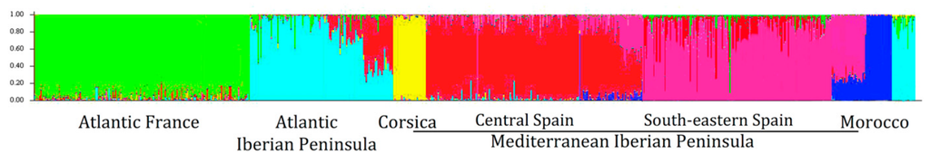

From Jamarillo-Correa et al. (2015)

According to Jamarillo-Correa et al. (2015):

- `Q1`: Northern Africa
- `Q2`: Corsica
- `Q3`: Central Spain
- `Q4`: Atlantic France
- `Q5`: Atlantic (Iberian)
- `Q6`: South-eastern Spain

## 2.2 A-matrix (GRM)

Load the grm built from "neutral" SNPs.

```r
A <- readRDS(file="../../data/GRMs/GRMVanRaden.RDS")
is.symmetric.matrix(A)
```

```
## [1] TRUE
```

```r
is.positive.definite(A)
```

```
## [1] TRUE
```

```r
A[1:10,1:10]
```

```
##            ALT1      ALT10      ALT2       ALT3       ALT4       ALT5       ALT6       ALT8      ALT9      ARM1
## ALT1  1.0782559 0.11870999 0.2322634 0.21990001 0.21673210 0.17454014 0.13280219 0.20094955 0.2839262 0.2856534
## ALT10 0.1187100 0.93406347 0.1224585 0.12311148 0.11644351 0.10346231 0.06539749 0.14157082 0.1381321 0.1317741
## ALT2  0.2322634 0.12245849 0.9817821 0.21194648 0.17010293 0.13645078 0.12942719 0.16445908 0.2078724 0.2086913
## ALT3  0.2199000 0.12311148 0.2119465 1.01534643 0.20946804 0.13173842 0.07554204 0.11479190 0.2613918 0.2165098
## ALT4  0.2167321 0.11644351 0.1701029 0.20946804 0.98201600 0.19657520 0.07900994 0.17952133 0.2179296 0.1944640
## ALT5  0.1745401 0.10346231 0.1364508 0.13173842 0.19657520 0.98614613 0.05901425 0.18965567 0.2207555 0.2091554
## ALT6  0.1328022 0.06539749 0.1294272 0.07554204 0.07900994 0.05901425 0.96315945 0.07133195 0.1410053 0.1297668
## ALT8  0.2009495 0.14157082 0.1644591 0.11479190 0.17952133 0.18965567 0.07133195 1.01651181 0.2191126 0.1826331
## ALT9  0.2839262 0.13813214 0.2078724 0.26139178 0.21792964 0.22075547 0.14100527 0.21911259 1.0868962 0.2906279
## ARM1  0.2856534 0.13177411 0.2086913 0.21650975 0.19446405 0.20915536 0.12976685 0.18263307 0.2906279 0.9946734
```

```r
range(A)
```

```
## [1] -0.2518075  1.9904276
```

## 2.3 Q-matrix

```r
Qmat <- sub.Q
row.names(Qmat) <- Qmat$clon
Qmat$clon <- NULL
names(Qmat)
```

```
## [1] "Q1" "Q2" "Q3" "Q4" "Q5" "Q6"
```

```r
identical(row.names(A),row.names(Qmat))
```

```
## [1] TRUE
```

```r
Qmat
```

```
##          Q1    Q2    Q3    Q4    Q5    Q6
## ALT1  0.001 0.000 0.001 0.027 0.971 0.000
## ALT10 0.003 0.000 0.386 0.062 0.548 0.001
## ALT2  0.001 0.000 0.001 0.135 0.863 0.000
## ALT3  0.014 0.001 0.004 0.113 0.868 0.000
## ALT4  0.002 0.001 0.008 0.178 0.811 0.000
## ALT5  0.002 0.000 0.089 0.127 0.762 0.020
## ALT6  0.004 0.000 0.492 0.003 0.501 0.000
## ALT8  0.001 0.000 0.002 0.178 0.819 0.000
## ALT9  0.002 0.000 0.000 0.001 0.997 0.000
## ARM1  0.001 0.000 0.001 0.001 0.995 0.002
## ARM10 0.002 0.020 0.001 0.001 0.975 0.001
## ARM3  0.001 0.000 0.012 0.001 0.985 0.001
## ARM4  0.001 0.000 0.001 0.005 0.993 0.000
## ARM5  0.001 0.000 0.057 0.016 0.926 0.000
## ARM6  0.002 0.004 0.001 0.001 0.992 0.000
## ARM7  0.001 0.028 0.003 0.000 0.967 0.001
## ARM9  0.033 0.002 0.097 0.021 0.841 0.006
## ARN10 0.019 0.001 0.895 0.072 0.008 0.005
## ARN11 0.007 0.001 0.937 0.001 0.011 0.043
## ARN12 0.001 0.005 0.936 0.003 0.027 0.028
## ARN13 0.004 0.000 0.993 0.000 0.001 0.002
## ARN15 0.003 0.002 0.936 0.002 0.011 0.046
## ARN16 0.003 0.002 0.928 0.001 0.003 0.063
## ARN18 0.024 0.000 0.973 0.001 0.001 0.001
## ARN19 0.016 0.001 0.936 0.013 0.002 0.032
## ARN2  0.006 0.015 0.973 0.001 0.001 0.004
## ARN20 0.031 0.000 0.962 0.004 0.001 0.002
## ARN21 0.010 0.005 0.979 0.002 0.003 0.001
## ARN25 0.005 0.000 0.962 0.004 0.027 0.002
## ARN26 0.007 0.001 0.945 0.027 0.021 0.000
## ARN27 0.002 0.003 0.991 0.000 0.001 0.003
## ARN28 0.022 0.000 0.972 0.001 0.001 0.004
## ARN30 0.008 0.001 0.956 0.003 0.025 0.007
## ARN4  0.002 0.004 0.969 0.007 0.018 0.000
## BAY1  0.020 0.002 0.963 0.008 0.006 0.001
## BAY10 0.002 0.000 0.939 0.043 0.010 0.006
## BAY11 0.004 0.001 0.938 0.054 0.002 0.001
## BAY12 0.001 0.000 0.996 0.001 0.000 0.002
## BAY13 0.001 0.000 0.996 0.001 0.000 0.002
```

[output cut: 469 more lines]

```
## VER22 0.001 0.000 0.001 0.998 0.000 0.000
## VER23 0.001 0.000 0.001 0.998 0.000 0.000
## VER24 0.001 0.001 0.001 0.993 0.001 0.003
## VER25 0.001 0.000 0.000 0.998 0.001 0.000
## VER26 0.002 0.000 0.016 0.952 0.027 0.003
## VER28 0.002 0.001 0.004 0.960 0.033 0.000
## VER29 0.006 0.001 0.015 0.975 0.003 0.000
## VER3  0.004 0.001 0.109 0.881 0.004 0.001
## VER30 0.001 0.002 0.004 0.985 0.008 0.000
## VER4  0.004 0.000 0.104 0.891 0.000 0.001
## VER5  0.001 0.000 0.001 0.995 0.001 0.002
## VER6  0.006 0.005 0.068 0.915 0.003 0.003
## VER7  0.002 0.000 0.105 0.891 0.001 0.001
## VER8  0.004 0.005 0.003 0.982 0.002 0.004
## VER9  0.001 0.006 0.001 0.992 0.000 0.000
```

# 3 Decomposition of the relatedness matrix A

Generalized Cholesky decomposition of $\mathbf{A}$ into:

$$\mathbf{A} = \mathbf{T} \mathbf{D} \mathbf{T}^\intercal$$

where $\mathbf{T}$ is lower triangular matrix with transposed $\mathbf{T}^\intercal$ , and $\mathbf{D} = \text{Diag}(d_{11},...,d_{nn})$ is a diagonal matrix with entries $d_{11},...,d_{nn}$. A useful property of the decomposition is that the matrices $\mathbf{T}$ and $\mathbf{D}$ have elegant interpretations: $\mathbf{T}$ traces the flow of alleles between genotypes, and the diagonal entries of $\mathbf{D}$ scales the Mendelian sampling variance.

- **Comment on $\mathbf{T}$:** Each off-diagonal entry in $\mathbf{T}$ corresponds to the relatedness coefficient (expected relatedness) between genotypes $g$. All diagonal elements are 1 and all elements below the diagonal in the respective column correspond to the expected proportion of the genome that is shared between genotypes.
- **Comment on $\mathbf{D}$:** In the absence of inbreeding, the diagonal entry $d_{gg}$ for genotype $g$ in $\mathbf{D}$ is $(1-0.5 p_{g})$, with $p_{g}$ corresponfing to the proportion of proportion of $g$'s ancestral genome that is known. Possible values are $p_{g} = 0, 0.5 \, \text{or} \, 1$ if no, one or two parents are known, respectively. This can be understood as follows: if, for example, one parent of an animal $g$ is unknown, its predicted genetic value is 0.5 times the genetic value of the known parent, but the other half of its genetic value is unknown. The deviation from the predicted genetic value that could be obtained if both parents were known is absorbed by the Mendelian sampling deviation. The respective variance thus contains the Mendelian sampling variance plus a variance that is due to the unknown parent. The more parents are unknown, the larger is this variance. In our case, the parents are unknown and we assume no ingenetic (as the seeds were collected 100 meters away), so $p_{g}=0$ and $d_{gg}=1$.
- This text comes from [Muff et al. (2019)](https://gsejournal.biomedcentral.com/track/pdf/10.1186/s12711-019-0449-7)

```r
A.gchol <- gchol(A)
# A.gchol[1:10,1:10]

# Matrix T
T <- as.matrix(A.gchol)
T[1:10,1:10]
```

```
##            ALT1      ALT10       ALT2       ALT3       ALT4       ALT5       ALT6      ALT8      ALT9 ARM1
## ALT1  1.0000000 0.00000000 0.00000000 0.00000000 0.00000000 0.00000000 0.00000000 0.0000000 0.0000000    0
## ALT10 0.1100945 1.00000000 0.00000000 0.00000000 0.00000000 0.00000000 0.00000000 0.0000000 0.0000000    0
## ALT2  0.2154066 0.10519890 1.00000000 0.00000000 0.00000000 0.00000000 0.00000000 0.0000000 0.0000000    0
## ALT3  0.2039405 0.10738581 0.16729725 1.00000000 0.00000000 0.00000000 0.00000000 0.0000000 0.0000000    0
## ALT4  0.2010025 0.10052453 0.12335389 0.14592608 1.00000000 0.00000000 0.00000000 0.0000000 0.0000000    0
## ALT5  0.1618727 0.09147334 0.09765093 0.07712402 0.14678880 1.00000000 0.00000000 0.0000000 0.0000000    0
## ALT6  0.1231639 0.05513250 0.10360608 0.02893973 0.03517484 0.01837505 1.00000000 0.0000000 0.0000000    0
## ALT8  0.1863654 0.12969397 0.11785196 0.04583459 0.12005582 0.12712526 0.02316084 1.0000000 0.0000000    0
## ALT9  0.2633198 0.11604139 0.14700077 0.18129728 0.12141372 0.13395297 0.08061704 0.1066848 1.0000000    0
## ARM1  0.2649217 0.10893148 0.14823318 0.13342045 0.10268267 0.12797284 0.07072014 0.0728885 0.1348353    1
```

```r
# Transpose of matrix T
Tt <- t(as.matrix(A.gchol))
Tt[1:10,1:10]
```

```
##       ALT1     ALT10      ALT2      ALT3      ALT4       ALT5       ALT6       ALT8       ALT9       ARM1
## ALT1     1 0.1100945 0.2154066 0.2039405 0.2010025 0.16187266 0.12316389 0.18636536 0.26331984 0.26492171
## ALT10    0 1.0000000 0.1051989 0.1073858 0.1005245 0.09147334 0.05513250 0.12969397 0.11604139 0.10893148
## ALT2     0 0.0000000 1.0000000 0.1672973 0.1233539 0.09765093 0.10360608 0.11785196 0.14700077 0.14823318
## ALT3     0 0.0000000 0.0000000 1.0000000 0.1459261 0.07712402 0.02893973 0.04583459 0.18129728 0.13342045
## ALT4     0 0.0000000 0.0000000 0.0000000 1.0000000 0.14678880 0.03517484 0.12005582 0.12141372 0.10268267
## ALT5     0 0.0000000 0.0000000 0.0000000 0.0000000 1.00000000 0.01837505 0.12712526 0.13395297 0.12797284
## ALT6     0 0.0000000 0.0000000 0.0000000 0.0000000 0.00000000 1.00000000 0.02316084 0.08061704 0.07072014
## ALT8     0 0.0000000 0.0000000 0.0000000 0.0000000 0.00000000 0.00000000 1.00000000 0.10668484 0.07288850
## ALT9     0 0.0000000 0.0000000 0.0000000 0.0000000 0.00000000 0.00000000 0.00000000 1.00000000 0.13483525
## ARM1     0 0.0000000 0.0000000 0.0000000 0.0000000 0.00000000 0.00000000 0.00000000 0.00000000 1.00000000
```

```r
# diagonal matrix D
diag.A <- diag(A.gchol) # vector of numeric values
D <- Diagonal(x=diag.A)
D[1:10,1:10]
```

```
## 10 x 10 diagonal matrix of class "ddiMatrix"
##       [,1]     [,2]      [,3]      [,4]      [,5]      [,6]      [,7]      [,8]      [,9]      [,10]
##  [1,] 1.078256         .         .         .         .         .         .         .         .         .
##  [2,]        . 0.9209942         .         .         .         .         .         .         .         .
##  [3,]        .         . 0.9215585         .         .         .         .         .         .         .
##  [4,]        .         .         . 0.9340864         .         .         .         .         .         .
##  [5,]        .         .         .         . 0.8952321         .         .         .         .         .
##  [6,]        .         .         .         .         . 0.9165533         .         .         .         .
##  [7,]        .         .         .         .         .         . 0.9319119         .         .         .
##  [8,]        .         .         .         .         .         .         . 0.9205927         .         .
##  [9,]        .         .         .         .         .         .         .         . 0.9029373         .
## [10,]        .         .         .         .         .         .         .         .         . 0.8207748
```

```r
# checking that we find the same value
Abis <- T %*%  D %*% Tt
Abis <- as.matrix(Abis)
all.equal(A,Abis)
```

```
## [1] TRUE
```

```r
rm(Abis)
```

# 4 Group-specific matrices $\mathbf{A}_{j}$

In our case, we have $r$ = 6 gene pools. For each gene pool $j$, we want to compute the respective genomic relatedness matrices $\mathbf{A}_{j}$ , which can be decomposed like we did for $\mathbf{A}$:

$$\mathbf{A}_{j} = \mathbf{T}_{j} \mathbf{D}_{j} \mathbf{T}_{j}^\intercal$$

## 4.1 Calculate $\mathbf{T}_{j}$

$$\mathbf{T}_{j} = \mathbf{T} \cdot \text{Diag}(q_{j})$$

where $\text{Diag}(q_{j})$ is a diagonal matrix with diagonal equal to $q_{j}$.

```r
# Let's calculate T1
D1 <- Diagonal(x=Qmat[,1])
T1 <- T %*% D1
T1[1:10,1:10]
```

```
## 10 x 10 sparse Matrix of class "dtCMatrix"
```

```
##    [[ suppressing 10 column names 'ALT1', 'ALT10', 'ALT2' ... ]]
```

```
##
## ALT1  0.0010000000 .            .            .            .            .            .            .            .            .
## ALT10 0.0001100945 0.0030000000 .            .            .            .            .            .            .            .
## ALT2  0.0002154066 0.0003155967 1.000000e-03 .            .            .            .            .            .            .
## ALT3  0.0002039405 0.0003221574 1.672973e-04 0.0140000000 .            .            .            .            .            .
## ALT4  0.0002010025 0.0003015736 1.233539e-04 0.0020429651 2.000000e-03 .            .            .            .            .
## ALT5  0.0001618727 0.0002744200 9.765093e-05 0.0010797363 2.935776e-04 2.000000e-03 .            .            .            .
## ALT6  0.0001231639 0.0001653975 1.036061e-04 0.0004051563 7.034967e-05 3.675009e-05 4.000000e-03 .            .            .
## ALT8  0.0001863654 0.0003890819 1.178520e-04 0.0006416842 2.401116e-04 2.542505e-04 9.264334e-05 0.0010000000 .            .
## ALT9  0.0002633198 0.0003481242 1.470008e-04 0.0025381620 2.428274e-04 2.679059e-04 3.224682e-04 0.0001066848 0.0020000000 .
## ARM1  0.0002649217 0.0003267944 1.482332e-04 0.0018678863 2.053653e-04 2.559457e-04 2.828806e-04 0.0000728885 0.0002696705 0.001
```

Let's do the same for the other gene pools:

```r
# T2
D2 <- Diagonal(x=Qmat[,2])
T2 <- T %*% D2
T2[1:10,1:10]
```

```
## 10 x 10 sparse Matrix of class "dtCMatrix"
##
## ALT1  . . . .            .            . . . . .
## ALT10 . . . .            .            . . . . .
## ALT2  . . . .            .            . . . . .
## ALT3  . . . 1.000000e-03 .            . . . . .
## ALT4  . . . 1.459261e-04 1.000000e-03 . . . . .
## ALT5  . . . 7.712402e-05 1.467888e-04 . . . . .
## ALT6  . . . 2.893973e-05 3.517484e-05 . . . . .
## ALT8  . . . 4.583459e-05 1.200558e-04 . . . . .
## ALT9  . . . 1.812973e-04 1.214137e-04 . . . . .
## ARM1  . . . 1.334204e-04 1.026827e-04 . . . . .
```

```r
# T3
D3 <- Diagonal(x=Qmat[,3])
T3 <- T %*% D3
T3[1:10,1:10]
```

```
## 10 x 10 sparse Matrix of class "dtCMatrix"
##
## ALT1  0.0010000000 .          .            .            .            .           .          .            . .
## ALT10 0.0001100945 0.38600000 .            .            .            .           .          .            . .
## ALT2  0.0002154066 0.04060678 1.000000e-03 .            .            .           .          .            . .
## ALT3  0.0002039405 0.04145092 1.672973e-04 0.0040000000 .            .           .          .            . .
## ALT4  0.0002010025 0.03880247 1.233539e-04 0.0005837043 0.0080000000 .           .          .            . .
## ALT5  0.0001618727 0.03530871 9.765093e-05 0.0003084961 0.0011743104 0.089000000 .          .            . .
## ALT6  0.0001231639 0.02128114 1.036061e-04 0.0001157589 0.0002813987 0.001635379 0.49200000 .            . .
## ALT8  0.0001863654 0.05006187 1.178520e-04 0.0001833383 0.0009604466 0.011314148 0.01139513 0.0020000000 . .
## ALT9  0.0002633198 0.04479198 1.470008e-04 0.0007251891 0.0009713098 0.011921814 0.03966358 0.0002133697 . .
## ARM1  0.0002649217 0.04204755 1.482332e-04 0.0005336818 0.0008214613 0.011389583 0.03479431 0.0001457770 . 0.001
```

```r
# T4
D4 <- Diagonal(x=Qmat[,4])
T4 <- T %*% D4
T4[1:10,1:10]
```

```
## 10 x 10 sparse Matrix of class "dtCMatrix"
##
## ALT1  0.027000000 .           .          .           .           .           .            .          .            .
## ALT10 0.002972550 0.062000000 .          .           .           .           .            .          .            .
## ALT2  0.005815978 0.006522332 0.13500000 .           .           .           .            .          .            .
## ALT3  0.005506393 0.006657920 0.02258513 0.113000000 .           .           .            .          .            .
## ALT4  0.005427067 0.006232521 0.01665278 0.016489647 0.178000000 .           .            .          .            .
## ALT5  0.004370562 0.005671347 0.01318288 0.008715014 0.026128406 0.127000000 .            .          .            .
## ALT6  0.003325425 0.003418215 0.01398682 0.003270190 0.006261121 0.002333631 3.000000e-03 .          .            .
## ALT8  0.005031865 0.008041026 0.01591002 0.005179308 0.021369937 0.016144908 6.948251e-05 0.17800000 .            .
## ALT9  0.007109636 0.007194566 0.01984510 0.020486593 0.021611643 0.017012027 2.418511e-04 0.01898990 0.0010000000 .
## ARM1  0.007152886 0.006753752 0.02001148 0.015076511 0.018277514 0.016252551 2.121604e-04 0.01297415 0.0001348353 0.001
```

```r
# T5
D5 <- Diagonal(x=Qmat[,5])
T5 <- T %*% D5
T5[1:10,1:10]
```

```
## 10 x 10 sparse Matrix of class "dtCMatrix"
##
## ALT1  0.9710000 .          .          .          .          .          .          .          .         .
## ALT10 0.1069017 0.54800000 .          .          .          .          .          .          .         .
## ALT2  0.2091598 0.05764900 0.86300000 .          .          .          .          .          .         .
## ALT3  0.1980262 0.05884742 0.14437753 0.86800000 .          .          .          .          .         .
## ALT4  0.1951734 0.05508744 0.10645441 0.12666383 0.81100000 .          .          .          .         .
## ALT5  0.1571783 0.05012739 0.08427275 0.06694365 0.11904572 0.76200000 .          .          .         .
## ALT6  0.1195921 0.03021261 0.08941205 0.02511969 0.02852679 0.01400179 0.50100000 .          .         .
## ALT8  0.1809608 0.07107230 0.10170625 0.03978442 0.09736527 0.09686945 0.01160358 0.81900000 .         .
## ALT9  0.2556836 0.06359068 0.12686167 0.15736604 0.09846653 0.10207216 0.04038914 0.08737488 0.9970000 .
## ARM1  0.2572390 0.05969445 0.12792524 0.11580895 0.08327564 0.09751531 0.03543079 0.05969568 0.1344307 0.995
```

```r
# T6
D6 <- Diagonal(x=Qmat[,6])
T6 <- T %*% D6
T6[1:10,1:10]
```

```
## 10 x 10 sparse Matrix of class "dtCMatrix"
##
## ALT1  . .            . . . .            . . . .
## ALT10 . 1.000000e-03 . . . .            . . . .
## ALT2  . 1.051989e-04 . . . .            . . . .
## ALT3  . 1.073858e-04 . . . .            . . . .
## ALT4  . 1.005245e-04 . . . .            . . . .
## ALT5  . 9.147334e-05 . . . 0.0200000000 . . . .
## ALT6  . 5.513250e-05 . . . 0.0003675009 . . . .
## ALT8  . 1.296940e-04 . . . 0.0025425052 . . . .
## ALT9  . 1.160414e-04 . . . 0.0026790594 . . . .
## ARM1  . 1.089315e-04 . . . 0.0025594569 . . . 0.002
```

## 4.2 Calculate $\mathbf{D}_{j}$

In [Muff et al. (2019)](https://gsejournal.biomedcentral.com/track/pdf/10.1186/s12711-019-0449-7), it is written: "[...] in the absence of inbreeding, $d_{gg} = 1 − 0.5p_{g}$ with $p_{g}$ representing the proportion of the ancestral genome that is known. To calculate the respective entries $d_{gg}^{(j)}$ in the specific matrix of gene pool $j$, we have to multiply $p_{g}$ by the proportions of genetic origin $q_{gj}$, because the respective product then corresponds to the ancestral proportions that are known within the respective gene pool $j$. In the case where only one parent is known, multiplication must be with the genetic proportion of the known parent, denoted here as $q_{gj}$ , because only this respective part of the ancestral genome within group $j$ is then known. This leads to:

$$\begin{equation}
d_{gg}^{(j)} =
\begin{cases}
1, & \text{if no parent is known}\\
1-0.25 \cdot q_{gj}^{(p)}, & \text{if one parent is known}\\
1-0.5 \cdot q_{gj}, & \text{if both parents are known}
\end{cases}
\end{equation}$$

In our case:

- we can make the assumption that we are in absence in inbreeding (as the seeds were collected 100 meters away).
- the parents are unknown

So $d_{gg}^{(j)} = 1$ for all genotypes $g$ in all gene pools $j$.

```r
diij <- rep(1,523)

# Using equation 10 of Muff et al. (2019) gives the same result:
# diij <- 1-Qmat[,1]*(1-rep(1,523))
```

Let's calculate $\mathbf{D}_{j}$ which is the same for all gene pool $j$.

```r
Dj <- Diagonal(x=diij)
Dj[1:10,1:10]
```

```
## 10 x 10 diagonal matrix of class "ddiMatrix"
##       [,1] [,2] [,3] [,4] [,5] [,6] [,7] [,8] [,9] [,10]
##  [1,]    1    .    .    .    .    .    .    .    .     .
##  [2,]    .    1    .    .    .    .    .    .    .     .
##  [3,]    .    .    1    .    .    .    .    .    .     .
##  [4,]    .    .    .    1    .    .    .    .    .     .
##  [5,]    .    .    .    .    1    .    .    .    .     .
##  [6,]    .    .    .    .    .    1    .    .    .     .
##  [7,]    .    .    .    .    .    .    1    .    .     .
##  [8,]    .    .    .    .    .    .    .    1    .     .
##  [9,]    .    .    .    .    .    .    .    .    1     .
## [10,]    .    .    .    .    .    .    .    .    .     1
```

## 4.3 Calculate $\mathbf{A}_{j}$

Reminder:

$$\mathbf{A}_{j} = \mathbf{T}_{j} \mathbf{D}_{j} \mathbf{T}_{j}^\intercal$$

> $\mathbf{A}_{1}$ (relatedness matrix specific of gene pool 1)

```r
A1 <- T1 %*%  Dj %*% t(T1)
A1[1:10,1:10]
```

```
## 10 x 10 sparse Matrix of class "dgCMatrix"
##
## ALT1  1.000000e-06 1.100945e-07 2.154066e-07 2.039405e-07 2.010025e-07 1.618727e-07 1.231639e-07 1.863654e-07 2.633198e-07 2.649217e-07
## ALT10 1.100945e-07 9.012121e-06 9.705052e-07 9.889250e-07 9.268501e-07 8.410813e-07 5.097521e-07 1.187764e-06 1.073363e-06 1.009550e-06
## ALT2  2.154066e-07 9.705052e-07 1.146001e-06 3.128992e-07 2.618268e-07 2.191254e-07 1.823353e-07 2.807893e-07 3.135884e-07 3.084343e-07
## ALT3  2.039405e-07 9.889250e-07 3.128992e-07 1.961734e-04 2.876029e-05 1.525406e-05 5.767923e-06 9.166648e-06 3.572471e-05 2.633451e-05
## ALT4  2.010025e-07 9.268501e-07 2.618268e-07 2.876029e-05 8.320271e-06 2.920359e-06 1.055835e-06 1.960496e-06 5.847077e-06 4.396845e-06
## ALT5  1.618727e-07 8.410813e-07 2.191254e-07 1.525406e-05 2.920359e-06 5.363063e-06 6.070577e-07 1.420290e-06 3.500157e-06 2.736044e-06
## ALT6  1.231639e-07 5.097521e-07 1.823353e-07 5.767923e-06 1.055835e-06 6.070577e-07 1.622371e-05 7.563081e-07 2.450394e-06 2.014199e-06
## ALT8  1.863654e-07 1.187764e-06 2.807893e-07 9.166648e-06 1.960496e-06 1.420290e-06 7.563081e-07 1.742644e-06 2.093526e-06 1.606065e-06
## ALT9  2.633198e-07 1.073363e-06 3.135884e-07 3.572471e-05 5.847077e-06 3.500157e-06 2.450394e-06 2.093526e-06 1.090051e-05 5.703087e-06
## ARM1  2.649217e-07 1.009550e-06 3.084343e-07 2.633451e-05 4.396845e-06 2.736044e-06 2.014199e-06 1.606065e-06 5.703087e-06 4.953690e-06
```

```r
is.symmetric.matrix(as.matrix(A1)) # The matrix is symetric
```

```
## [1] TRUE
```

```r
is.positive.definite(as.matrix(A1)) # The matrix is not positive definite
```

```
## [1] FALSE
```

```r
A1pd <- nearPD(A1) # Function to approximate the nearest positive definite matrix
all.equal(as.matrix(A1),as.matrix(A1pd$mat))
```

```
## [1] "Mean relative difference: 1.638111e-05"
```

> $\mathbf{A}_{2}$ (relatedness matrix specific of gene pool 2)

```r
A2 <- T2 %*%  Dj %*% t(T2)
is.symmetric.matrix(as.matrix(A2))
```

```
## [1] TRUE
```

```r
is.positive.definite(as.matrix(A2))
```

```
## [1] FALSE
```

```r
A2[1:10,1:10]
```

```
## 10 x 10 sparse Matrix of class "dgCMatrix"
##
## ALT1  . . . .            .            .            .            .            .            .
## ALT10 . . . .            .            .            .            .            .            .
## ALT2  . . . .            .            .            .            .            .            .
## ALT3  . . . 1.000000e-06 1.459261e-07 7.712402e-08 2.893973e-08 4.583459e-08 1.812973e-07 1.334204e-07
## ALT4  . . . 1.459261e-07 1.021294e-06 1.580432e-07 3.939790e-08 1.267443e-07 1.478697e-07 1.221522e-07
## ALT5  . . . 7.712402e-08 1.580432e-07 2.749507e-08 7.395221e-09 2.115780e-08 3.180455e-08 2.536259e-08
## ALT6  . . . 2.893973e-08 3.939790e-08 7.395221e-09 2.074777e-09 5.549385e-09 9.517403e-09 7.472998e-09
## ALT8  . . . 4.583459e-08 1.267443e-07 2.115780e-08 5.549385e-09 1.651421e-08 2.288611e-08 1.844292e-08
## ALT9  . . . 1.812973e-07 1.478697e-07 3.180455e-08 9.517403e-09 2.288611e-08 4.761000e-08 3.665585e-08
## ARM1  . . . 1.334204e-07 1.221522e-07 2.536259e-08 7.472998e-09 1.844292e-08 3.665585e-08 2.834475e-08
```

```r
A2pd <- nearPD(A2)
all.equal(as.matrix(A2),as.matrix(A2pd$mat))
```

```
## [1] "Mean relative difference: 1.423373e-05"
```

> $\mathbf{A}_{3}$ (relatedness matrix specific of gene pool 3)

```r
A3 <- T3 %*%  Dj %*% t(T3)
is.symmetric.matrix(as.matrix(A3))
```

```
## [1] TRUE
```

```r
is.positive.definite(as.matrix(A3))
```

```
## [1] FALSE
```

```r
A3pd <- nearPD(A3)
all.equal(as.matrix(A3),as.matrix(A3pd$mat))
```

```
## [1] "Mean relative difference: 1.39828e-06"
```

> $\mathbf{A}_{4}$ (relatedness matrix specific of gene pool 4)

```r
A4 <- T4 %*%  Dj %*% t(T4)
is.symmetric.matrix(as.matrix(A4))
```

```
## [1] TRUE
```

```r
is.positive.definite(as.matrix(A4))
```

```
## [1] FALSE
```

```r
A4pd <- nearPD(A4)
all.equal(as.matrix(A4),as.matrix(A4pd$mat))
```

```
## [1] "Mean relative difference: 2.167834e-06"
```

> $\mathbf{A}_{5}$ (relatedness matrix specific of gene pool 5)

```r
A5 <- T5 %*%  Dj %*% t(T5)
is.symmetric.matrix(as.matrix(A5))
```

```
## [1] TRUE
```

```r
is.positive.definite(as.matrix(A5))
```

```
## [1] FALSE
```

```r
A5pd <- nearPD(A5)
all.equal(as.matrix(A5),as.matrix(A5pd$mat))
```

```
## [1] "Mean relative difference: 2.349564e-06"
```

```r
as.matrix(A5pd$mat)[1:10,1:10]
```

```
##            ALT1      ALT10       ALT2       ALT3       ALT4       ALT5       ALT6       ALT8       ALT9       ARM1
## ALT1  0.9428405 0.10380161 0.20309411 0.19228345 0.18951334 0.15262023 0.11612398 0.17571281 0.24826872 0.24977902
## ALT10 0.1038016 0.31173136 0.05395131 0.05341778 0.05105221 0.04427248 0.02934109 0.05829275 0.06218073 0.06021179
## ALT2  0.2030941 0.05395131 0.79183962 0.16940950 0.13586836 0.10849255 0.10391819 0.12971940 0.16662624 0.16764487
## ALT3  0.1922834 0.05341778 0.16940950 0.81694566 0.16720504 0.10434944 0.06017324 0.08923442 0.20928386 0.17344464
## ALT4  0.1895133 0.05105221 0.13586836 0.16720504 0.72622409 0.14743496 0.06084084 0.13406348 0.16669963 0.14931819
## ALT5  0.1526202 0.04427248 0.10849255 0.10434944 0.14743496 0.63361672 0.04359378 0.12864561 0.15410222 0.14617828
## ALT6  0.1161240 0.02934109 0.10391819 0.06017324 0.06084084 0.04359378 0.27585093 0.04382923 0.07226803 0.06840621
## ALT8  0.1757128 0.05829275 0.12971940 0.08923442 0.13406348 0.12864561 0.04382923 0.73948373 0.16145515 0.13526727
## ALT9  0.2482687 0.06218073 0.16662624 0.20928386 0.16669963 0.15410222 0.07226803 0.16145515 1.13366431 0.26284884
## ARM1  0.2497790 0.06021179 0.16764487 0.17344464 0.14931819 0.14617828 0.06840621 0.13526727 0.26284884 1.12887101
```

> $\mathbf{A}_{6}$ (relatedness matrix specific of gene pool 6)

```r
A6 <- T6 %*%  Dj %*% t(T6)
is.symmetric.matrix(as.matrix(A6))
```

```
## [1] TRUE
```

```r
is.positive.definite(as.matrix(A6))
```

```
## [1] FALSE
```

```r
A6pd <- nearPD(A6)
all.equal(as.matrix(A6),as.matrix(A6pd$mat))
```

```
## [1] "Mean relative difference: 6.43867e-06"
```

```r
as.matrix(A6pd$mat)[1:10,1:10]
```

```
##              ALT1        ALT10         ALT2         ALT3         ALT4         ALT5         ALT6         ALT8         ALT9         ARM1
## ALT1  4.22507e-08 0.000000e+00 0.000000e+00 0.000000e+00 0.000000e+00 0.000000e+00 0.000000e+00 0.000000e+00 0.000000e+00 0.000000e+00
## ALT10 0.00000e+00 5.719886e-08 4.511758e-09 4.604130e-09 4.314036e-09 1.233939e-07 3.996070e-09 2.072103e-08 2.095271e-08 2.389960e-07
## ALT2  0.00000e+00 4.511758e-09 4.225070e-08 6.329313e-10 5.930520e-10 1.696300e-08 5.493411e-10 2.848527e-09 2.880376e-09 3.285486e-08
## ALT3  0.00000e+00 4.604130e-09 6.329313e-10 4.225070e-08 6.051940e-10 1.731029e-08 5.605882e-10 2.906847e-09 2.939348e-09 3.352752e-08
## ALT4  0.00000e+00 4.314036e-09 5.930520e-10 6.051940e-10 4.225070e-08 1.621962e-08 5.252670e-10 2.723694e-09 2.754147e-09 3.141504e-08
## ALT5  0.00000e+00 1.233939e-07 1.696300e-08 1.731029e-08 1.621962e-08 3.998275e-04 6.421574e-06 5.067927e-05 5.341505e-05 5.099449e-05
## ALT6  0.00000e+00 3.996070e-09 5.493411e-10 5.605882e-10 5.252670e-10 6.421574e-06 1.354790e-07 8.143507e-07 8.582568e-07 8.328183e-07
## ALT8  0.00000e+00 2.072103e-08 2.848527e-09 2.906847e-09 2.723694e-09 5.067927e-05 8.143507e-07 6.467185e-06 6.771916e-06 6.498967e-06
## ALT9  0.00000e+00 2.095271e-08 2.880376e-09 2.939348e-09 2.754147e-09 5.341505e-05 8.582568e-07 6.771916e-06 7.179366e-06 6.843756e-06
## ARM1  0.00000e+00 2.389960e-07 3.285486e-08 3.352752e-08 3.141504e-08 5.099449e-05 8.328183e-07 6.498967e-06 6.843756e-06 9.587118e-06
```

# 5 Heatmaps of $\mathbf{A}_{j}$ matrices

## 5.1 Basic matrices

```r
heatmap(as.matrix(A1))
heatmap(as.matrix(A2))
heatmap(as.matrix(A3))
heatmap(as.matrix(A4))
heatmap(as.matrix(A5))
heatmap(as.matrix(A6))
```

## 5.2 With `gplots`

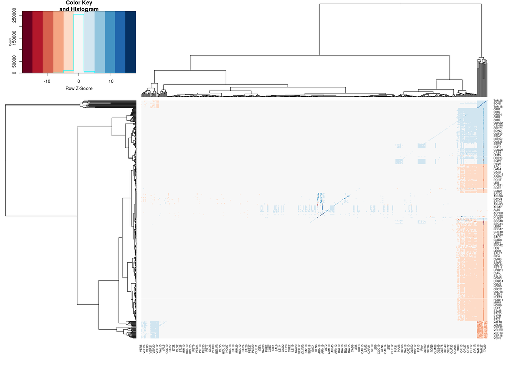

```r
heatmap.2(as.matrix(A1),scale="row",col=brewer.pal(11,"RdBu"),trace="none")
```

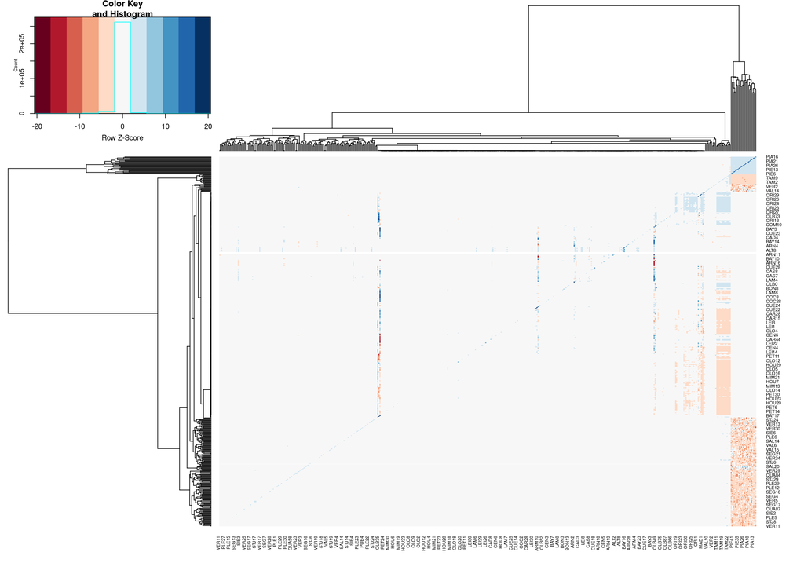

```r
heatmap.2(as.matrix(A2),scale="row",col=brewer.pal(11,"RdBu"),trace="none")
```

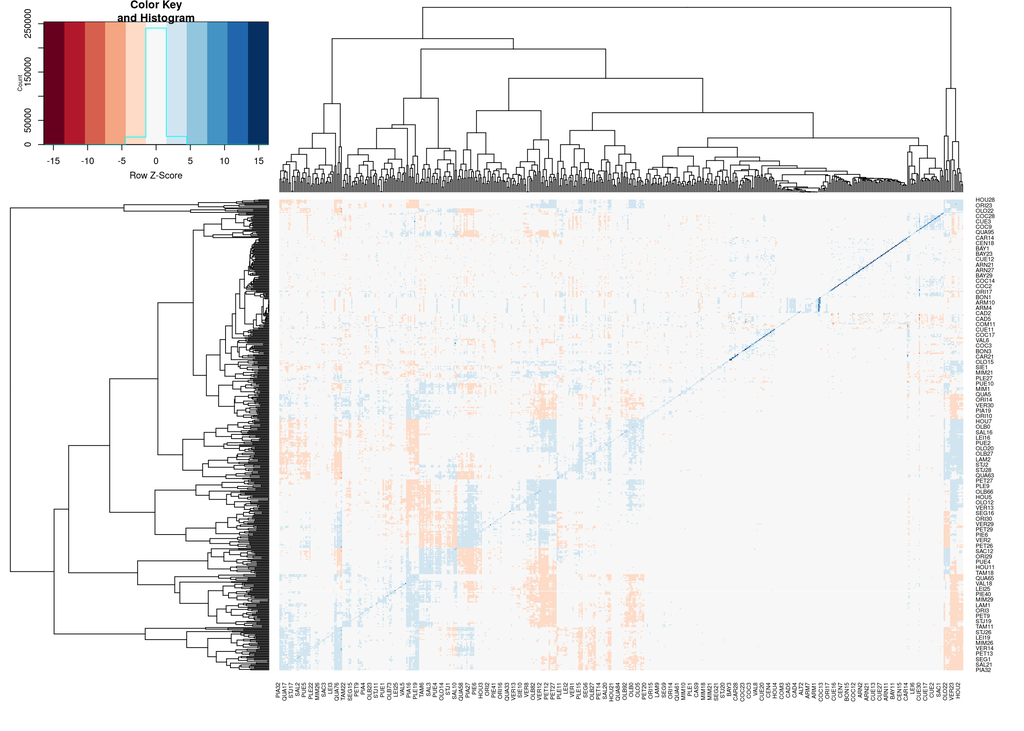

```r
heatmap.2(as.matrix(A3),scale="row",col=brewer.pal(11,"RdBu"),trace="none")
```